# residential_displacement

##### Household size

It’s difficult to interpret because of the large moes and the multiple dimensions. Some major conclusions could be:

- Households with children moved at higher rates in 2019 (before COVID)
- For 1-person households, more moved in 2021 (after COVID)

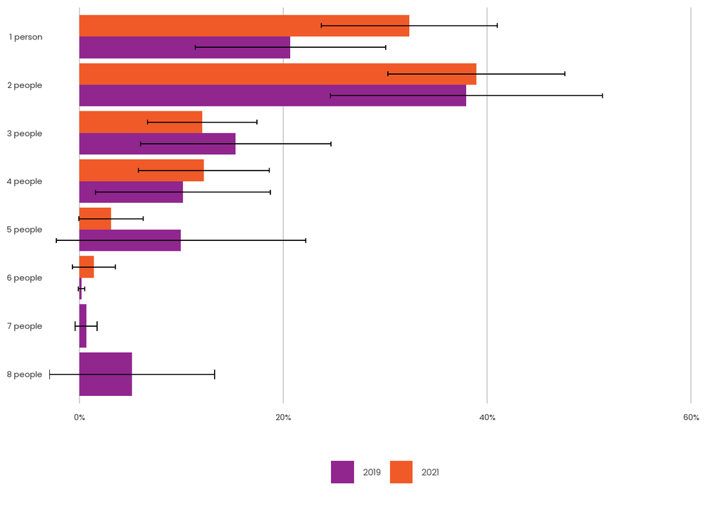

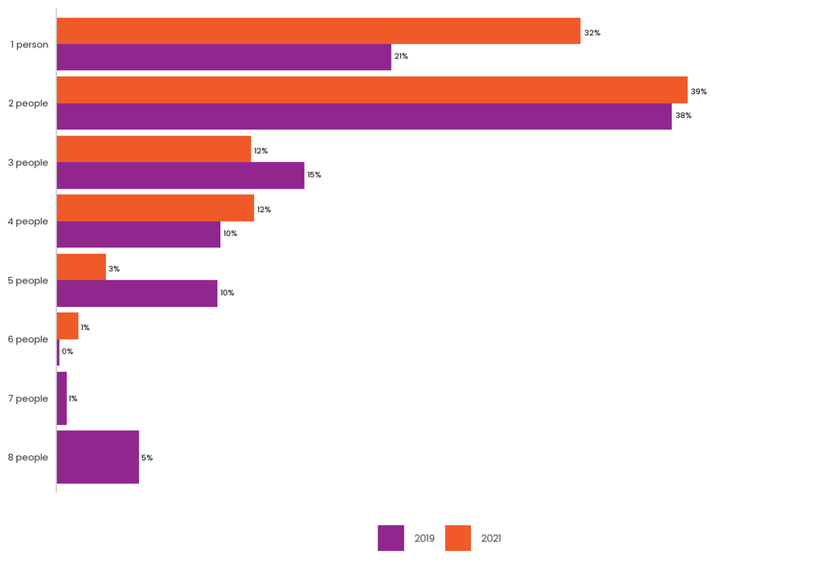

###### Simplified household size

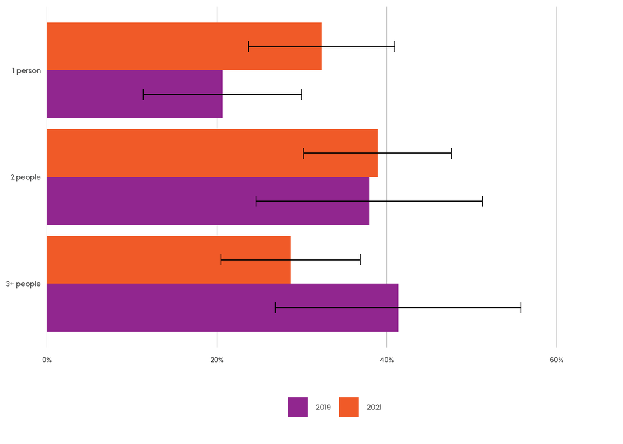

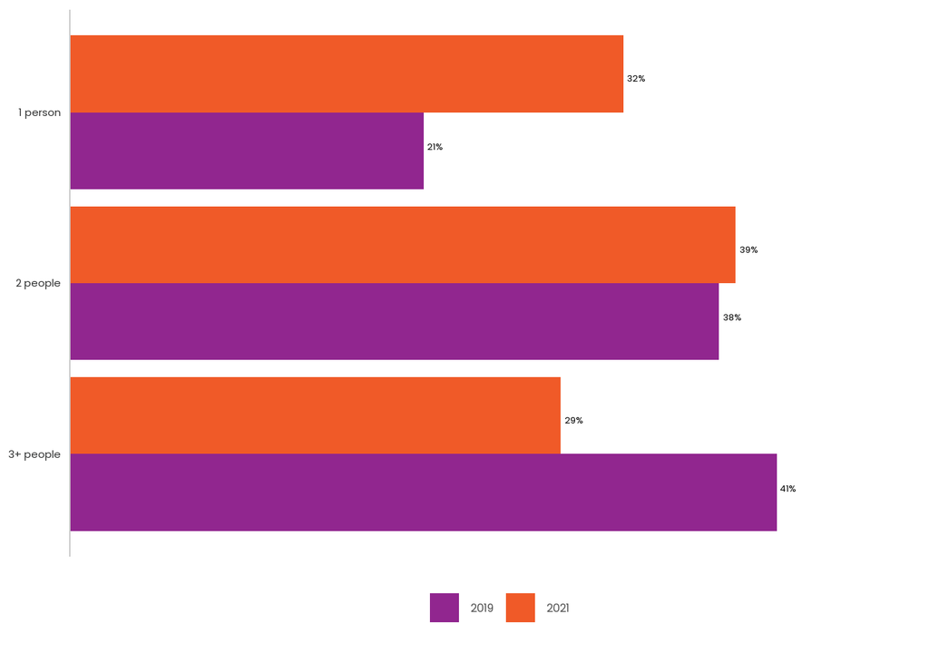

##### Life cylce

It’s difficult to interpret because of the large moes and the multiple dimensions. Some major conclusions could be:

- Households with children moved at higher rates in 2019 (before COVID)
- In 1-person households, more moved in 2021 (after COVID)

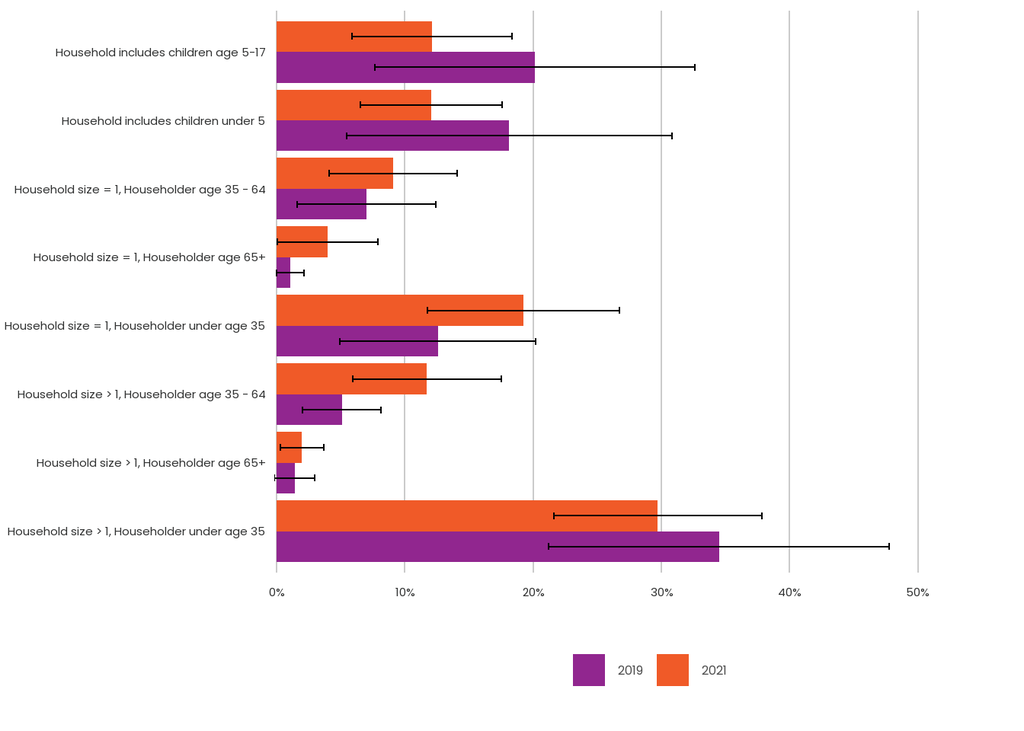

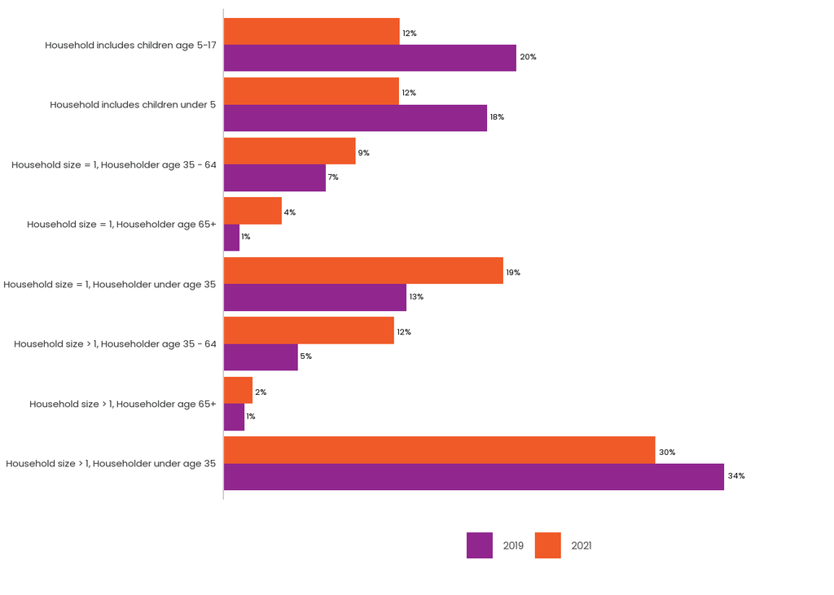

###### *Simplified life cycle*

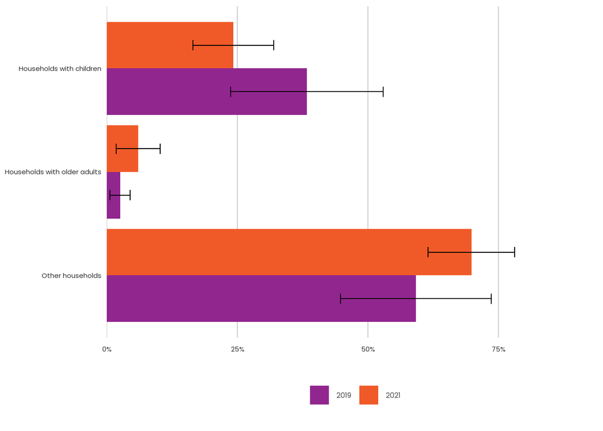

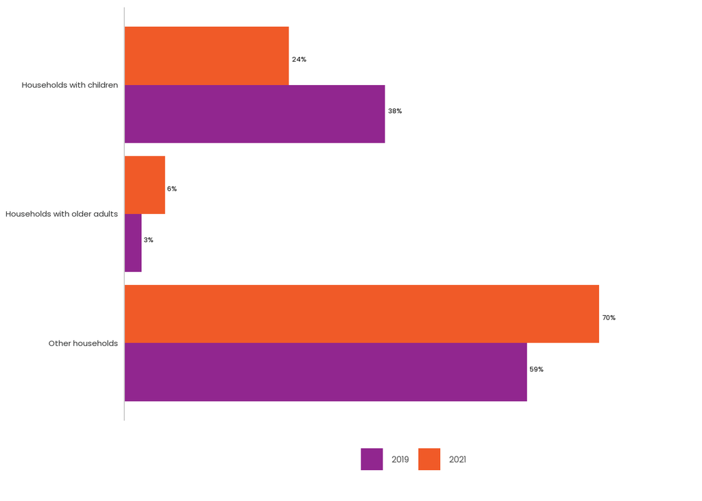

##### Tenure

###### Previous tenure

The majority of people who experienced displacement in both years were renters prior to moving.

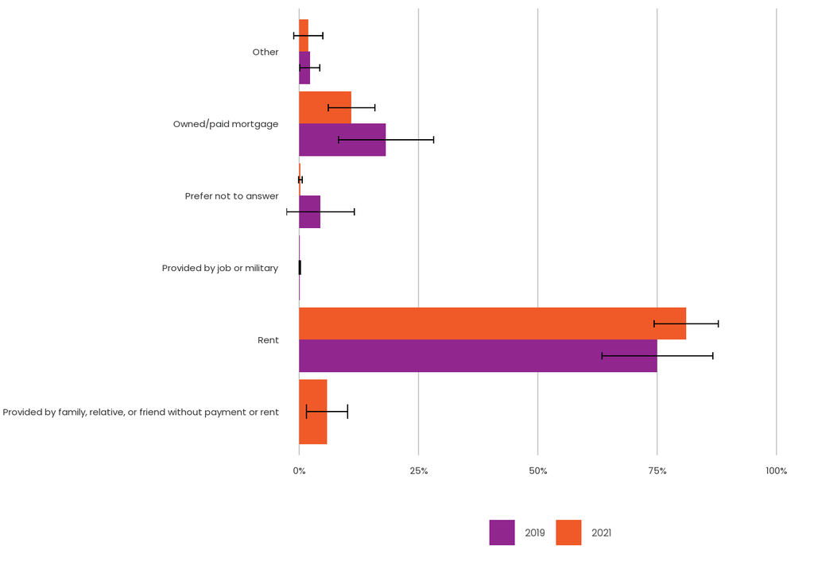

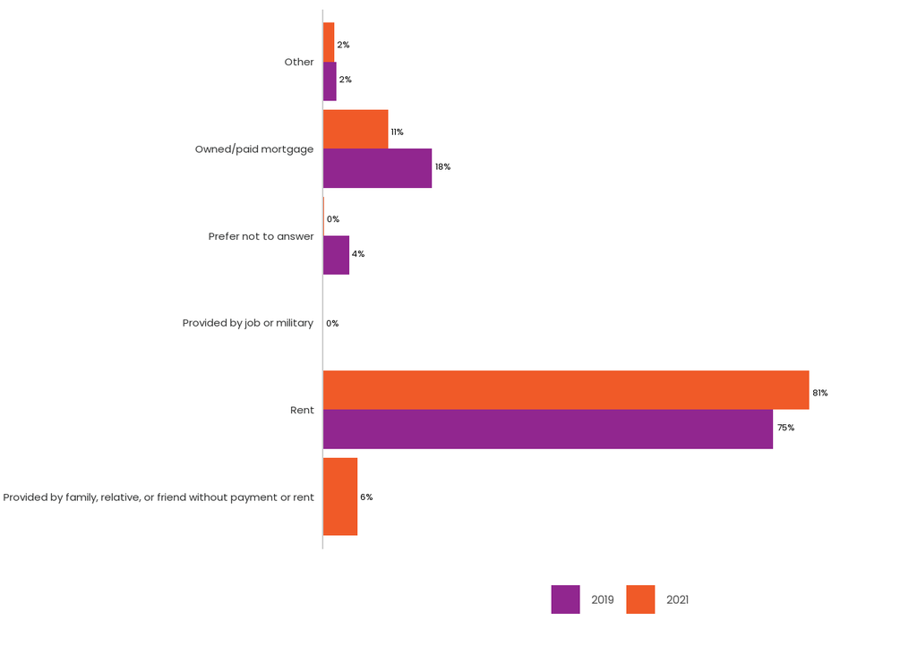

###### Current tenure

At the time of the survey, more respondents were renters than owners. The difference is more distinct for 2021 respondents.

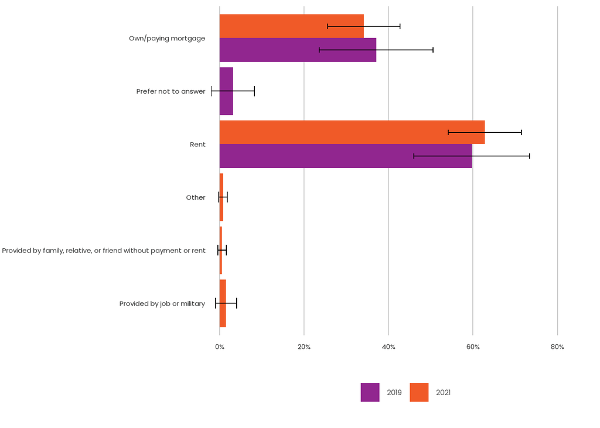

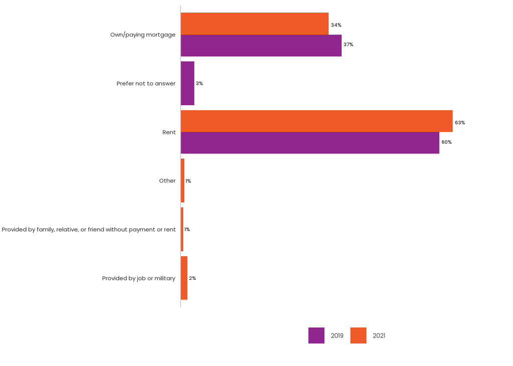

##### Residential type

###### Previous residential type

Large, overlapping moes.

- Pre-COVID (2019 survey), a large share of the households who moved had previously lived in SF
- After COVID (2021 survey), a large share of the households who moved had previously lived in 4+ apartment/condo buildings

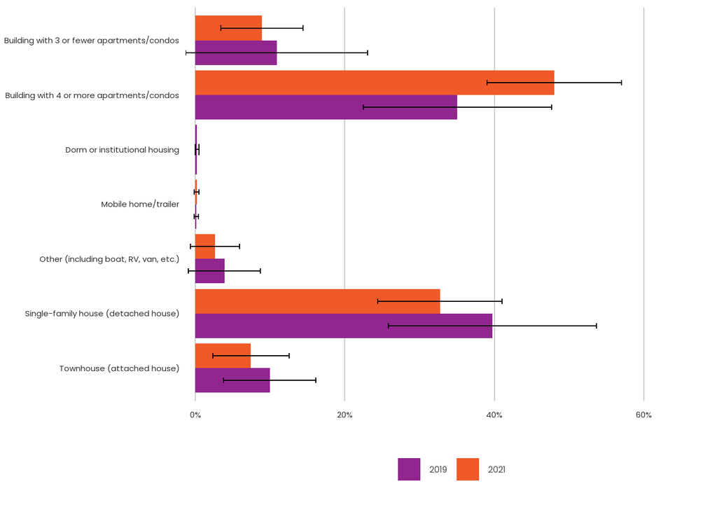

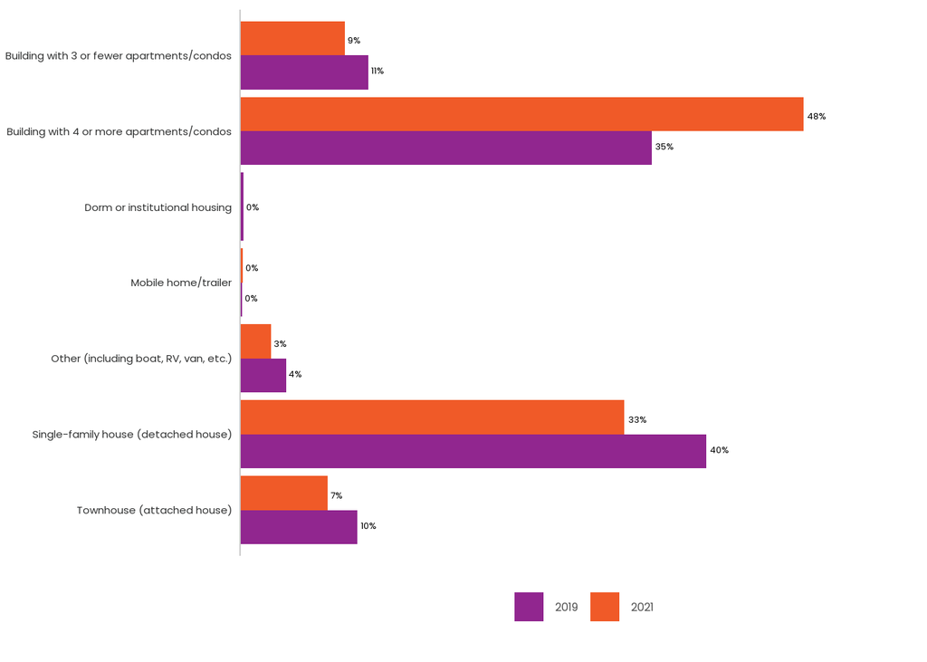

###### *Simplified previous*

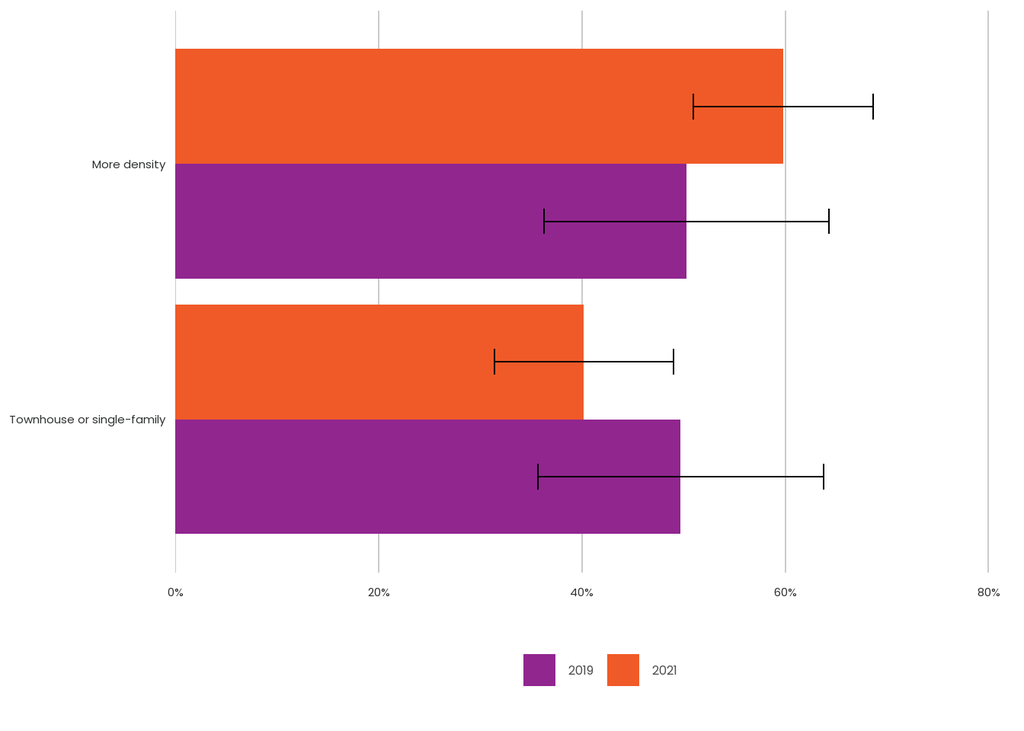

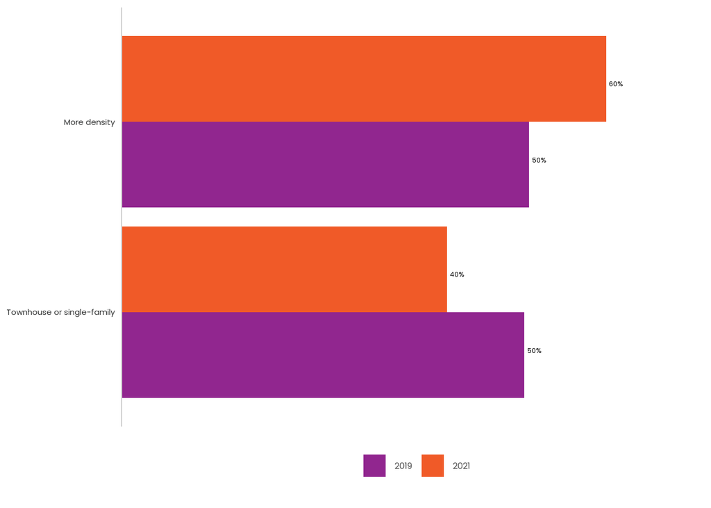

###### Current residential type

Large, overlapping moes.

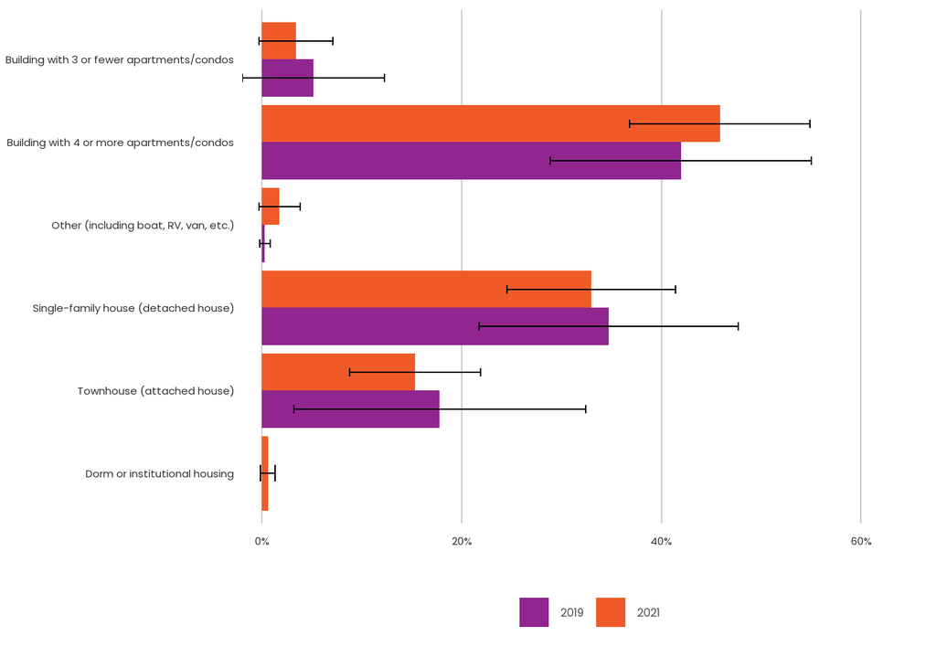

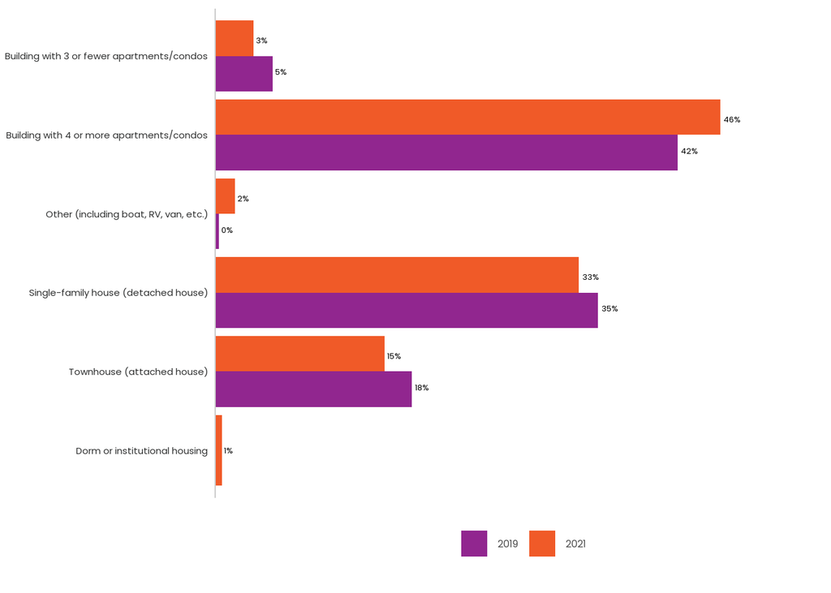

###### *Simplified current*

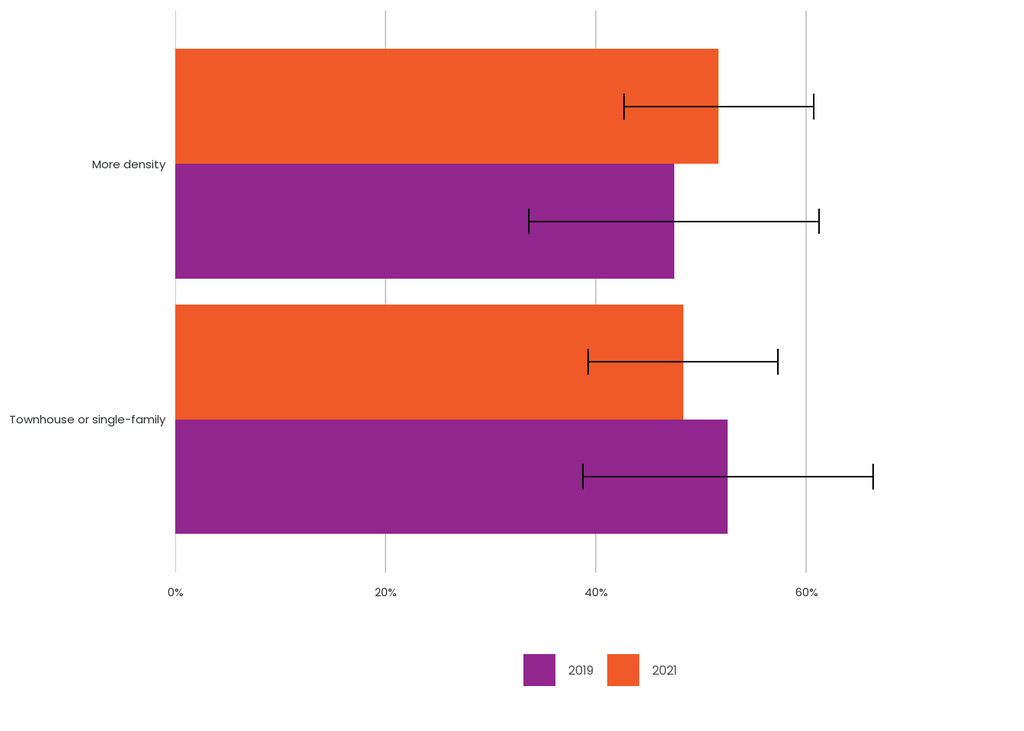

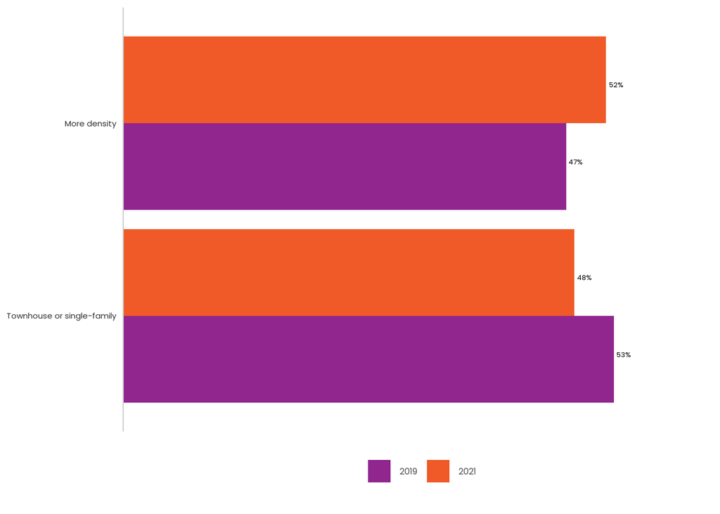

##### Vehicle ownership

It’s difficult to interpret because of the large moes. Households with 1 or 2 vehicles were more likely to move, both in 2019 and 2021.

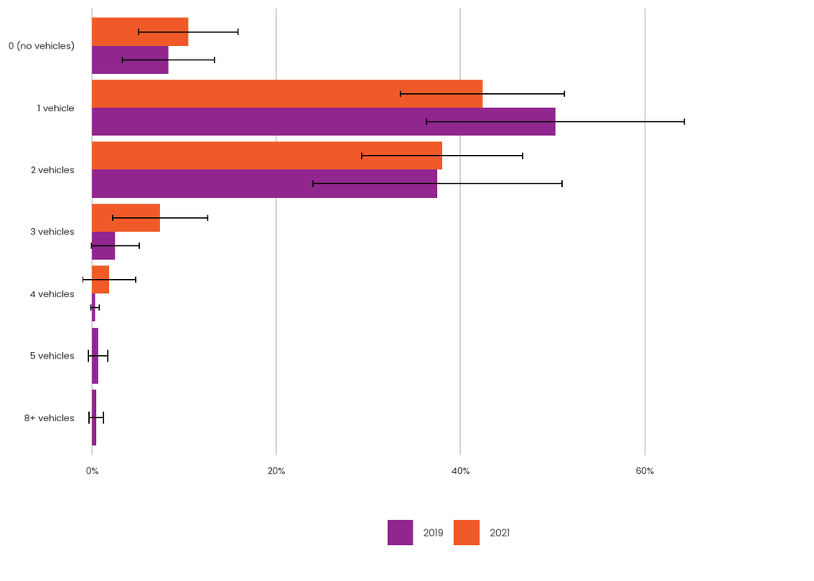

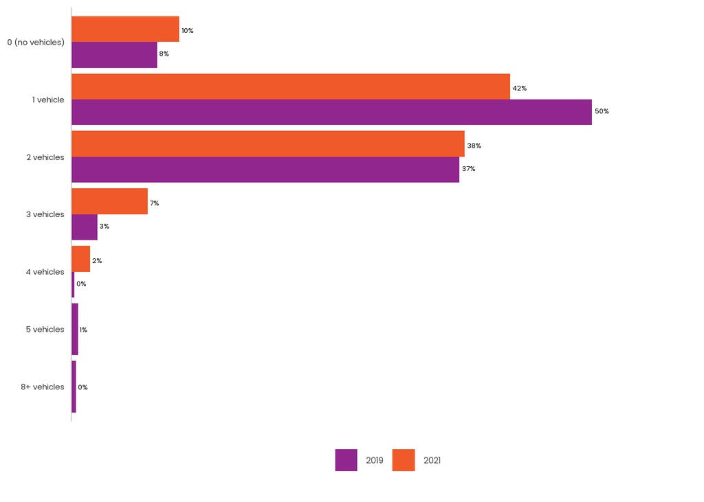

###### Simplified vehicle ownership

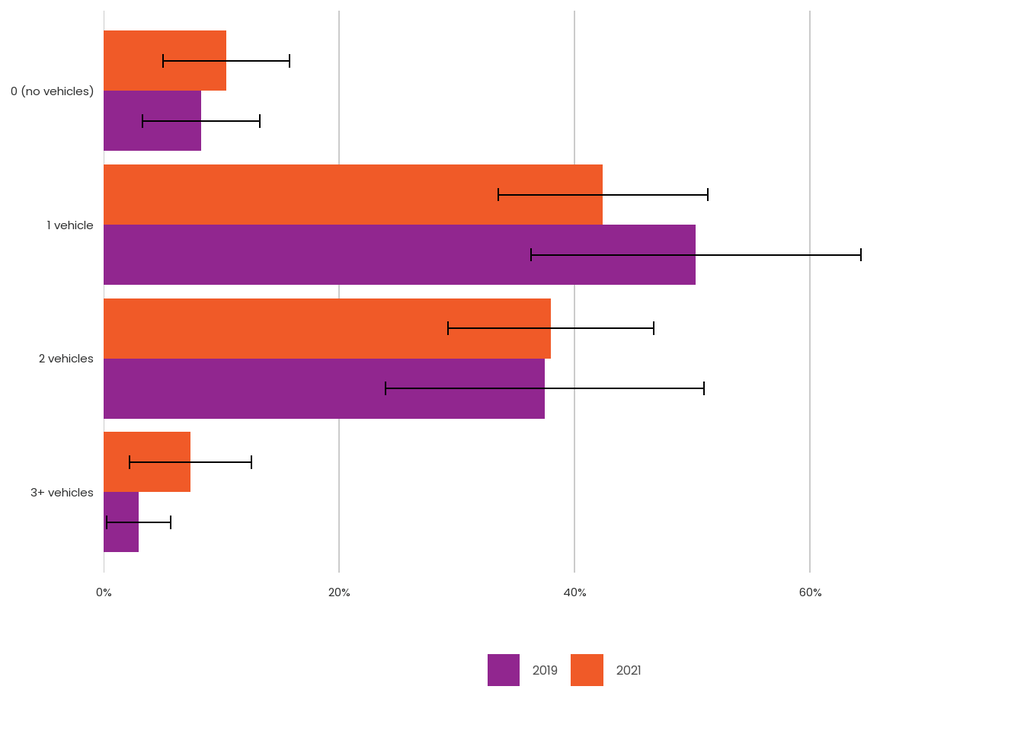

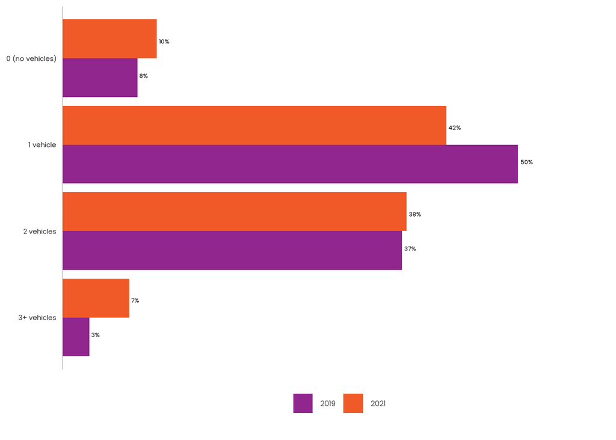

#### Past 1 year - displaced movers

Both datasets in the past 1 year (“Less than a year”). Limiting it to within one year of the survey means that there is no overlap between the samples and we are looking at the households that moved before COVID (spring/summer 2018-2019) and during COVID (spring/summer 2020-2021) *and selected a reason that indicated they were displaced*.

- 2019: 266 not displaced, 95 displaced = 361
- 2021: 145 not displaced, 53 displaced = 198

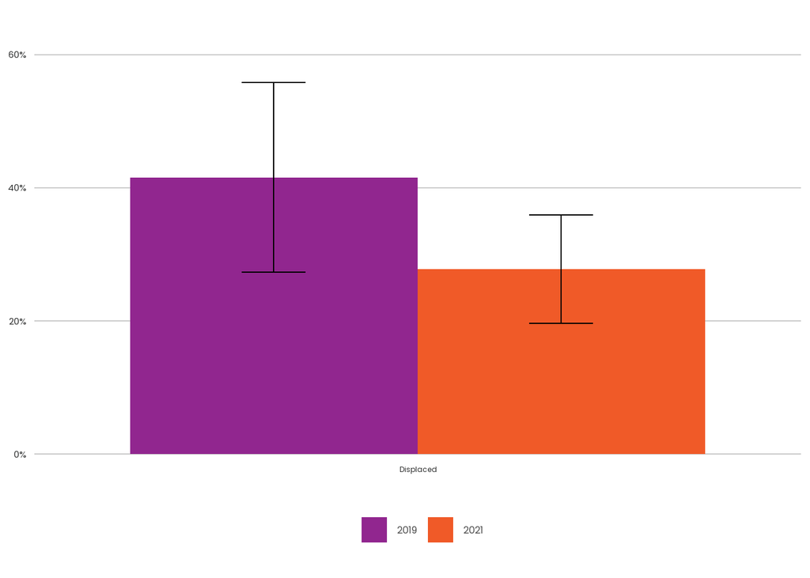

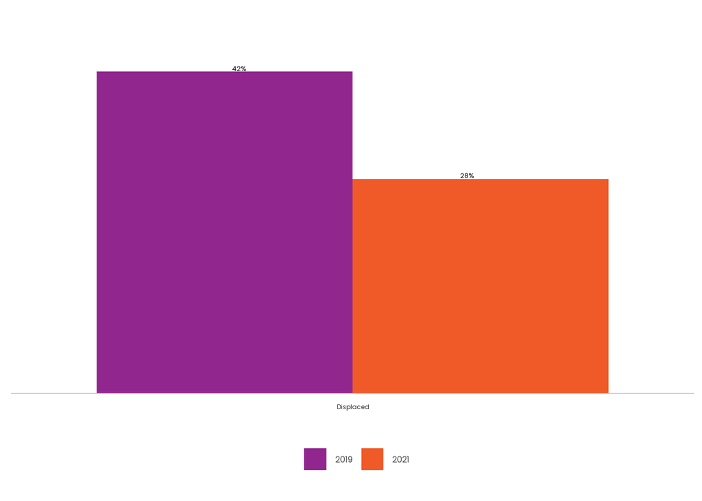

##### Race

###### 5 race categories

Both datasets in the past 1 year by **race**. The sample sizes by race and year are very small:

- African American: 7 | 1
- Asian: 16 | 13
- Hispanic: 6 | 7
- Other: 13 | 4
- White only: 48 | 27

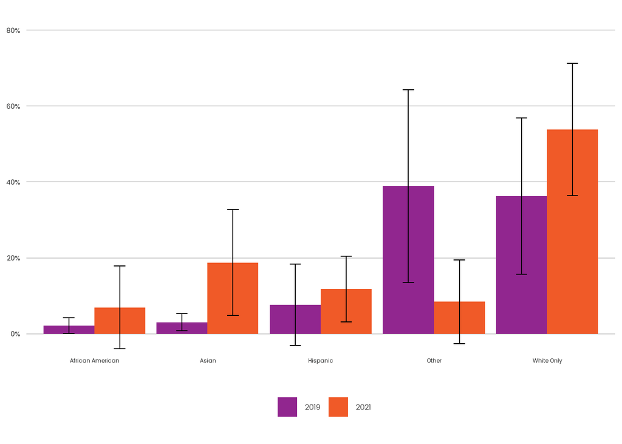

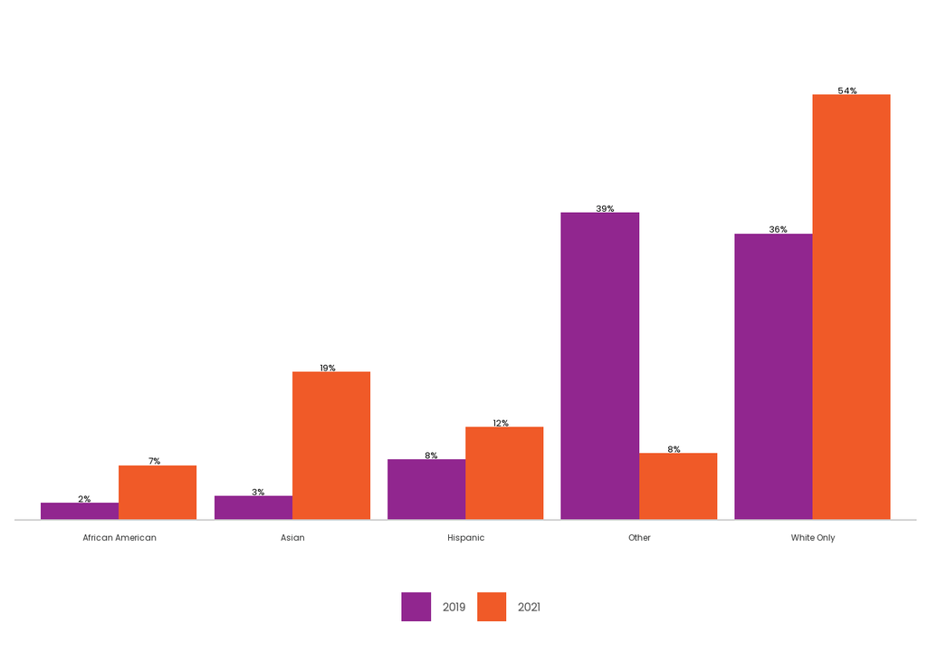

###### 3 race categories

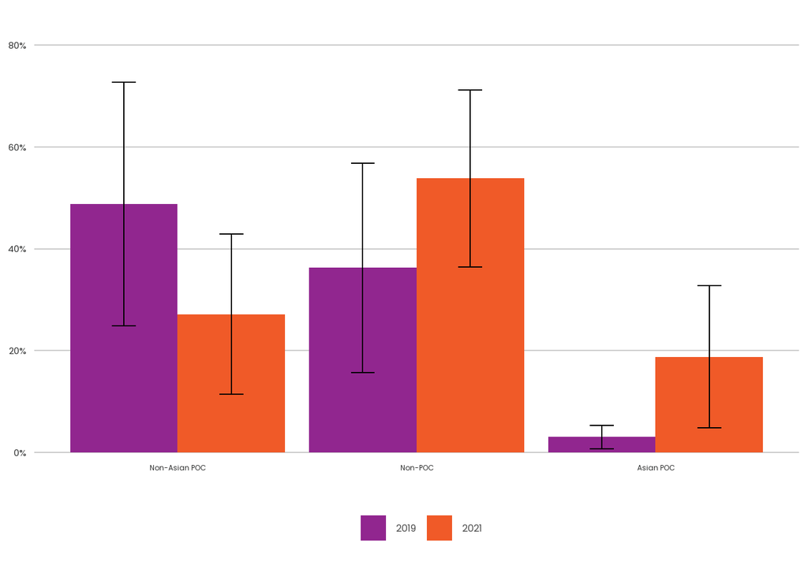

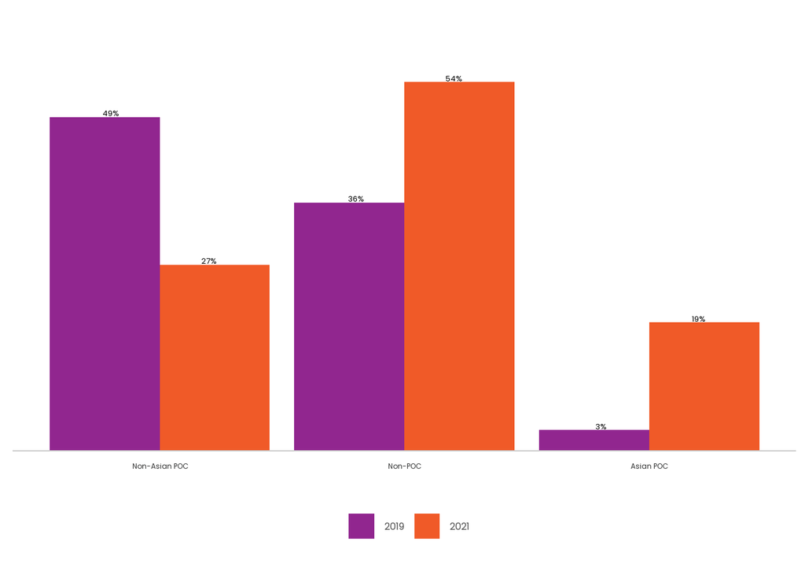

###### 2 race categories

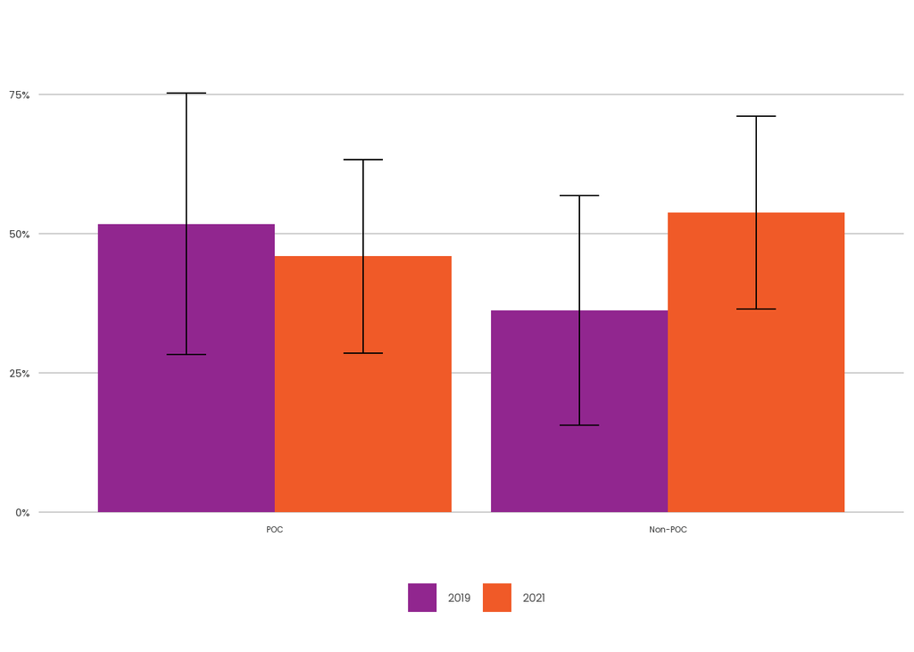

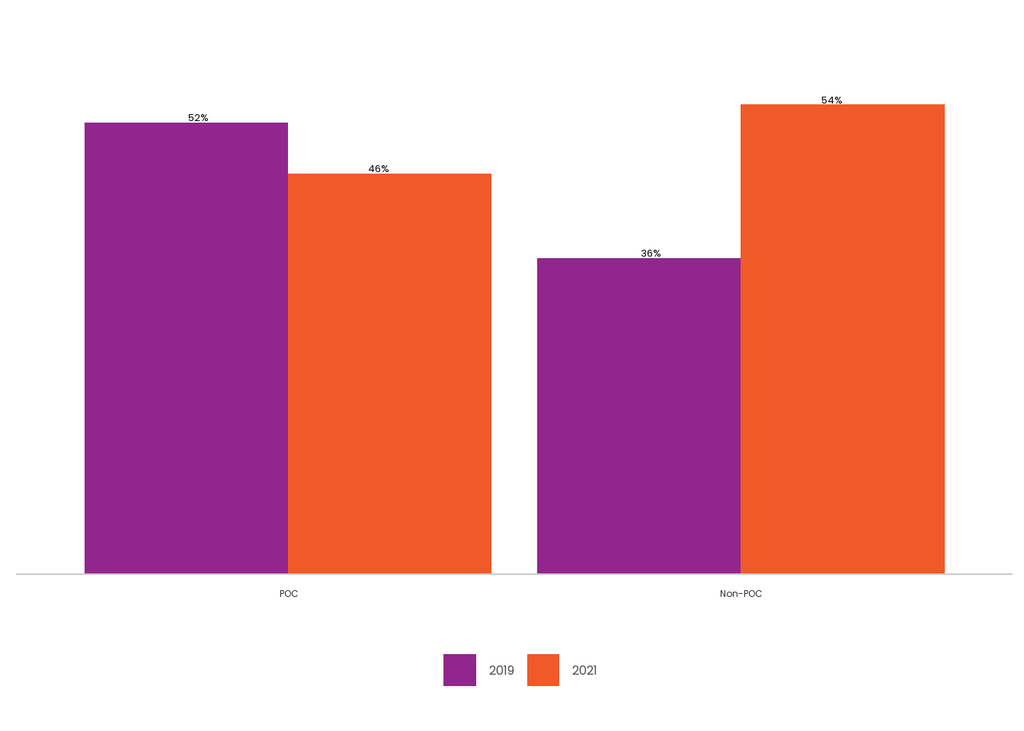

###### 2 race categories: 2017-2021

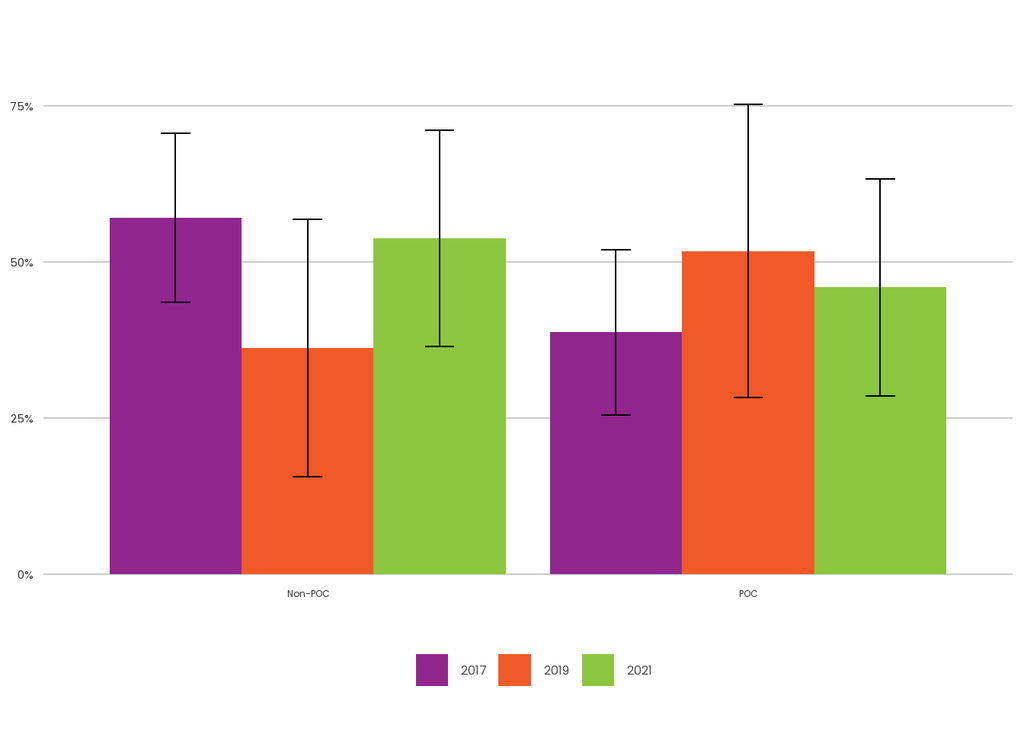

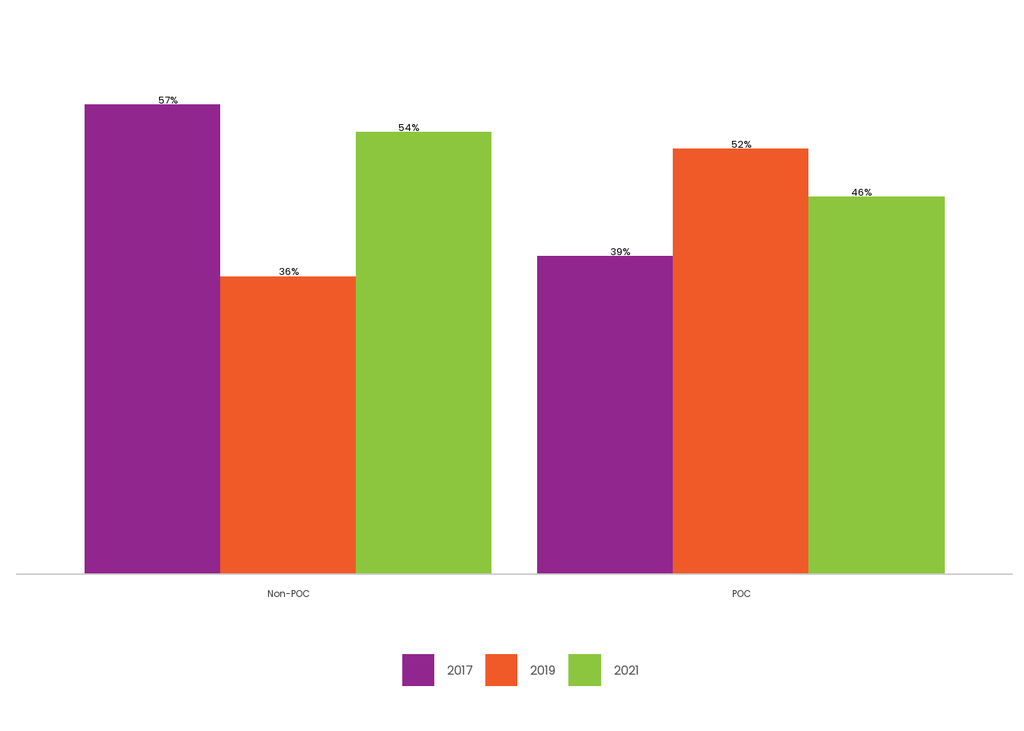

##### Income

Both datasets in the past 1 year by **income**. The sample sizes by race and year are very small:

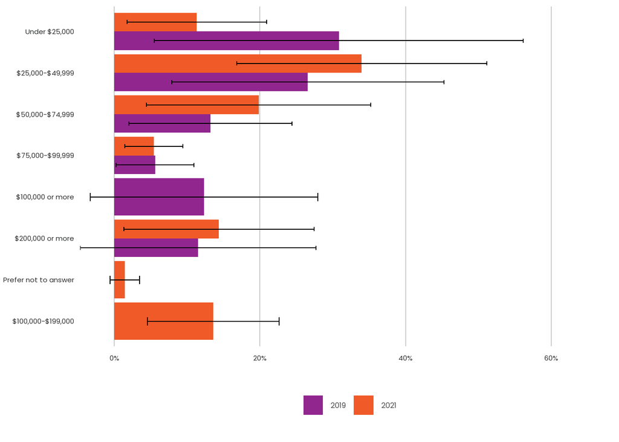

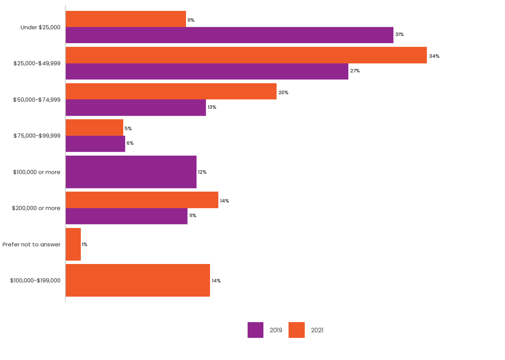

###### Simplified income categories

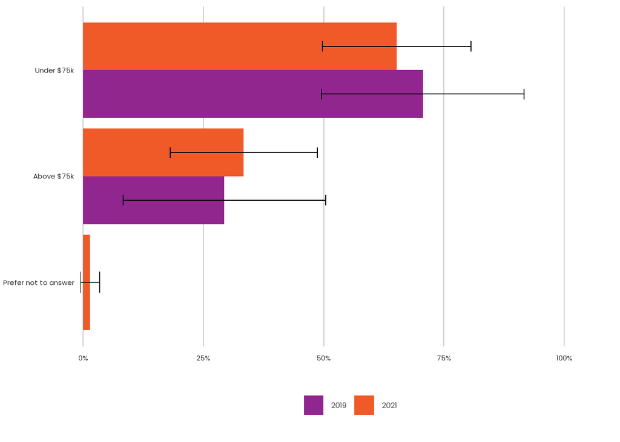

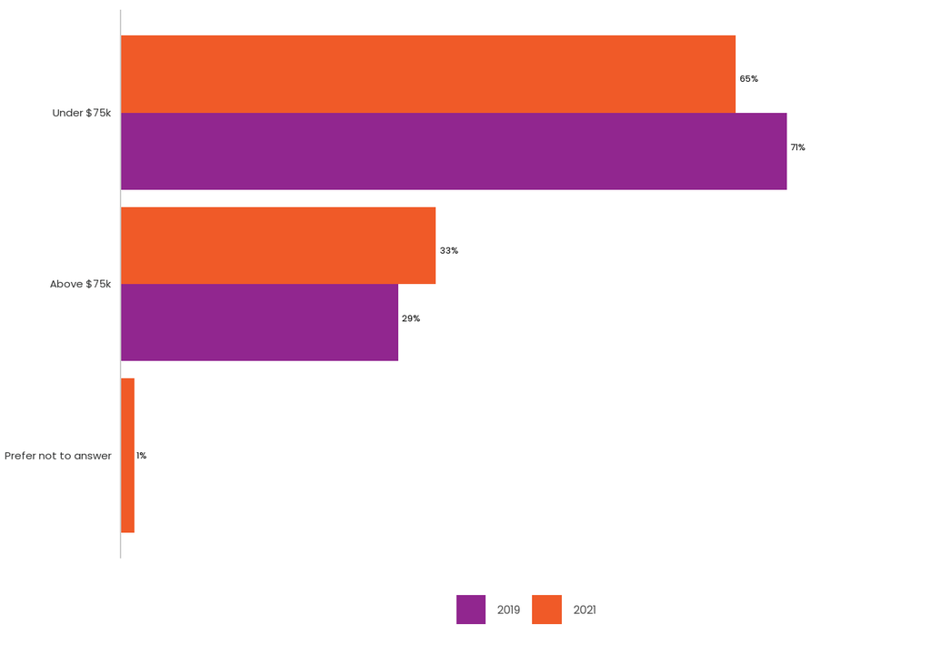

##### Regional growth center

Both data sets in the past 1 year by final home address location within or outside of a regional growth center. THe moes are large and overlapping.

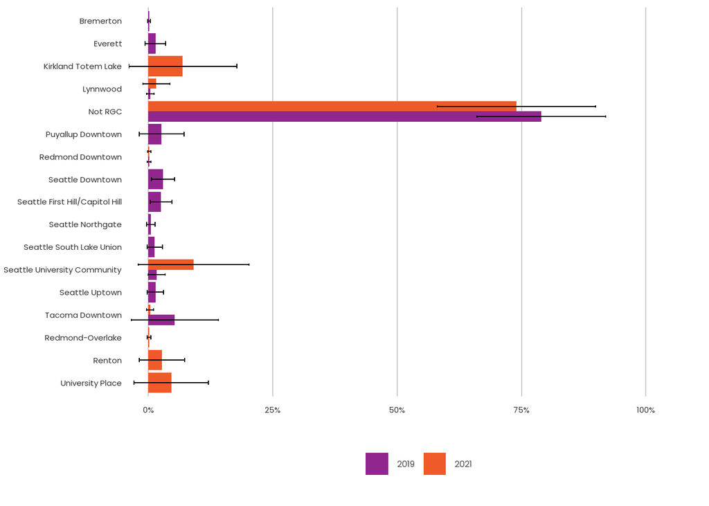

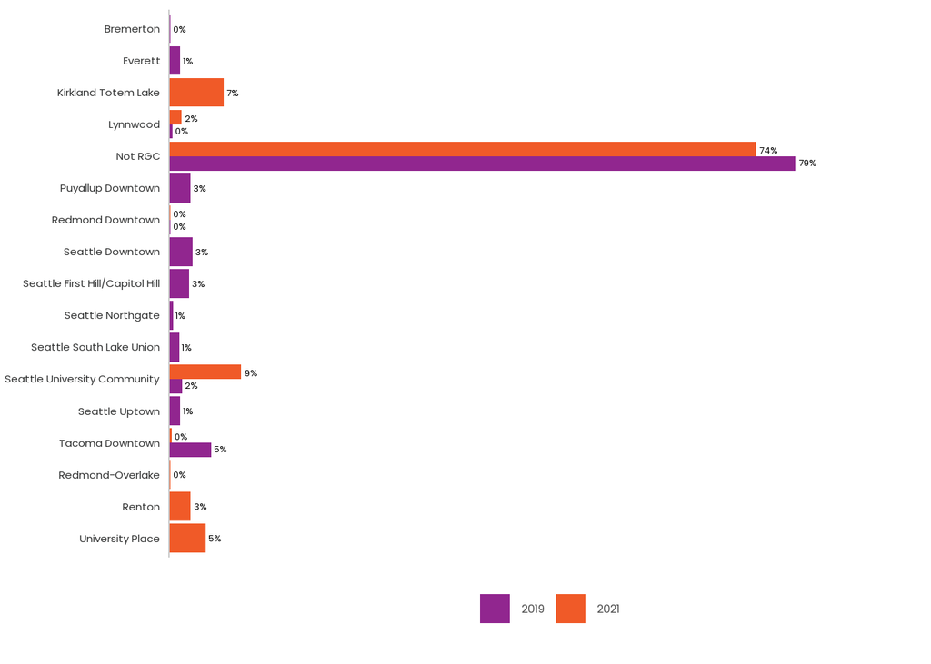

###### Simplified RGC: 3 categories

The RGS are categorized as urban or metro  
**Metro**: Bellevue, Bremerton, Everett, Redmond Downtown, Seattle Downtown, Seattle First Hill/Capitol Hill, Seattle Northgate, Seattle South Lake Union, Seattle University Community, Seattle Uptown, Tacoma Downtown  
**Urban** : Bothell Canyon Park, Issaquah, Kirkland Totem Lake, Lynnwood, Puyallup Downtown, Puyallup South Hill

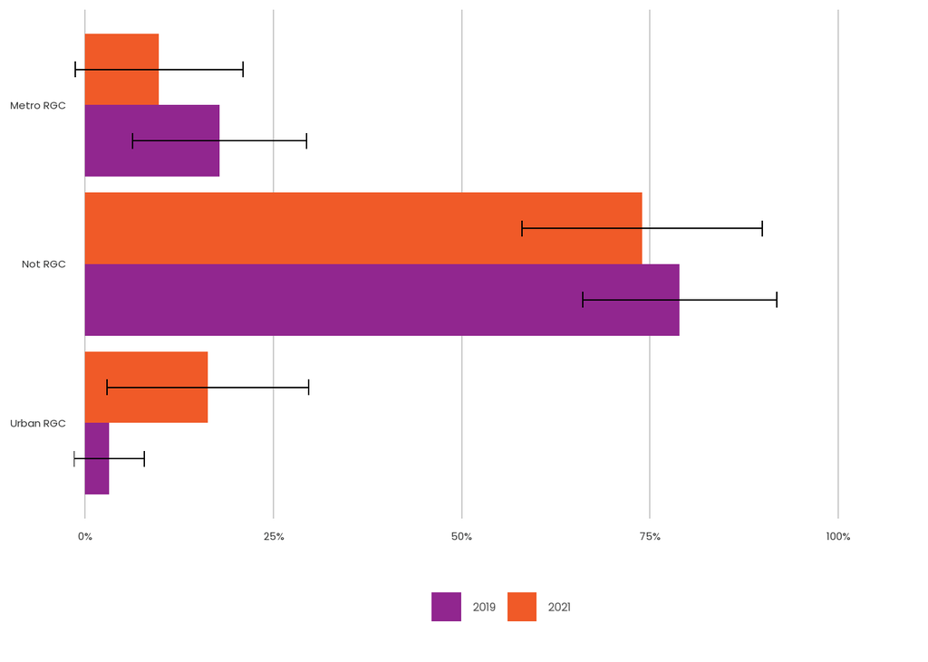

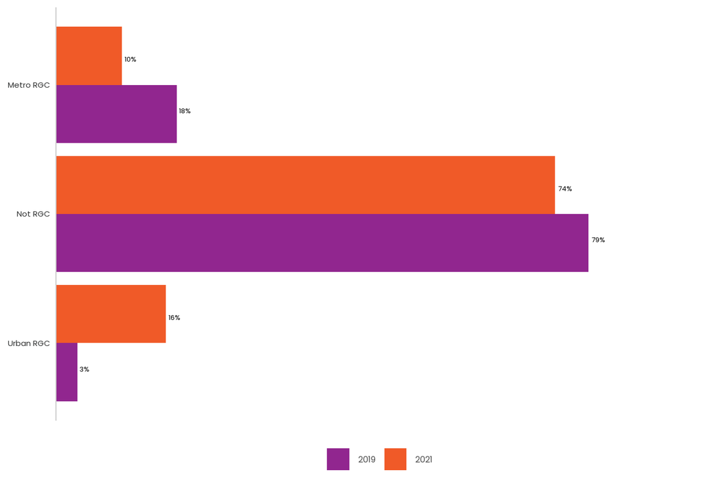

###### Simplified RGC: 2 categories

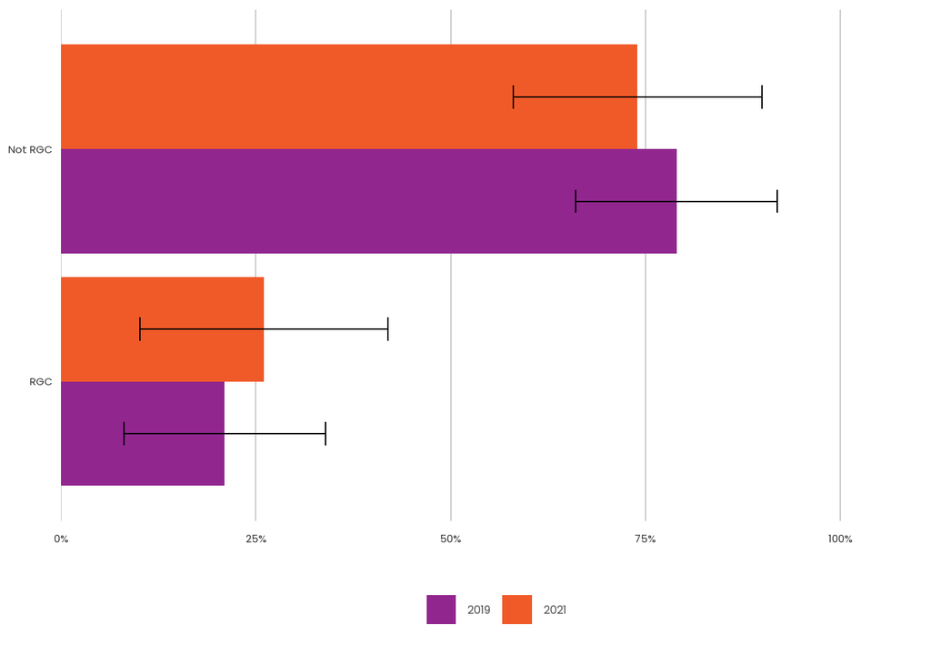

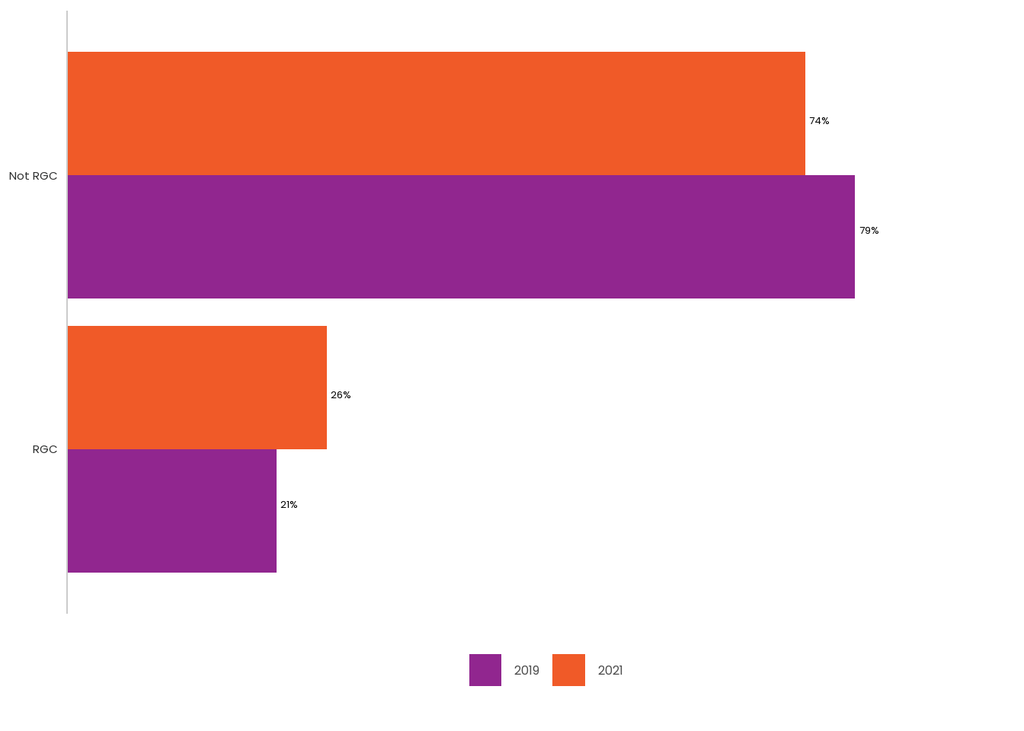

##### Household size

It’s difficult to interpret because of the large moes. It appears that 1-person households were more likely to report moving because of displacement in 2021 (after COVID), than in 2019. Households with 2 people seem similar, but those with 3 or more peole experienced displacement at higher rates in 2019.

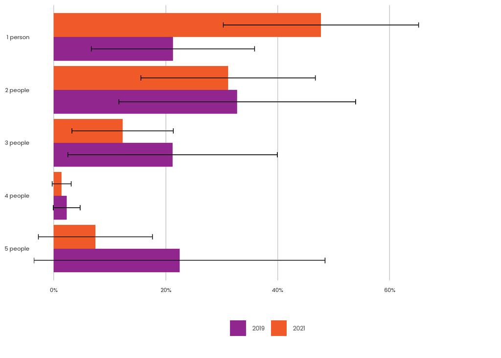

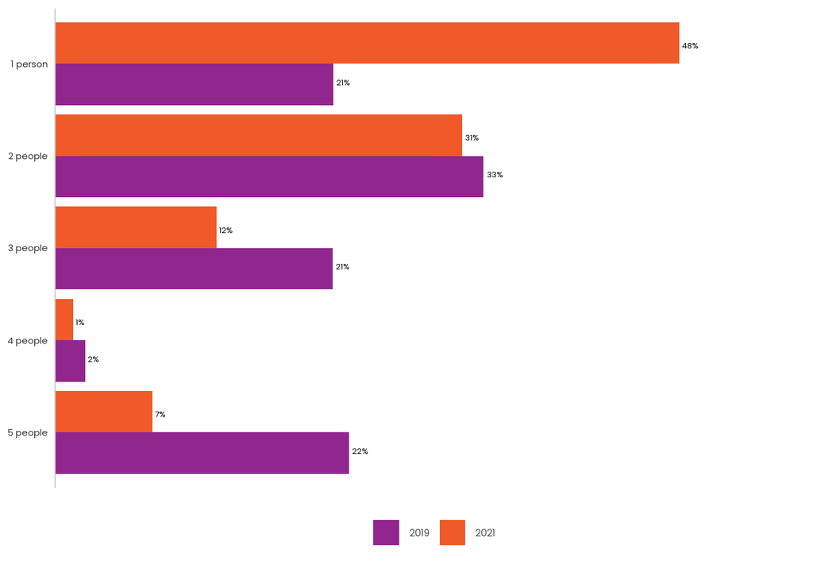

###### Simplified household size

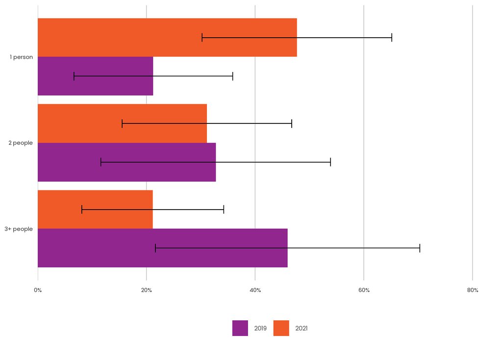

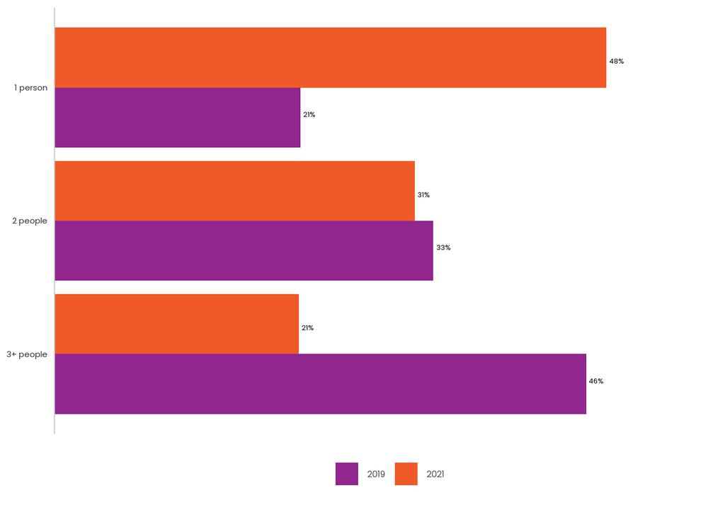

##### Life cylce

It’s difficult to interpret because of the large moes and the multiple dimensions. Some major conclusions could be:

- Households with children <5 experienced displacement at higher rates in 2019 (before COVID)
  - There doesn’t appear to be a change over between before/after COVID for households with children 5-17
- In 1-person households, displacement impacted people under 35 and over 65 after COVID, more so than before COVID
  - People 35-64 don’t show much change
- In households with more than 1 person, 35-64 was impacted more after COVID than before

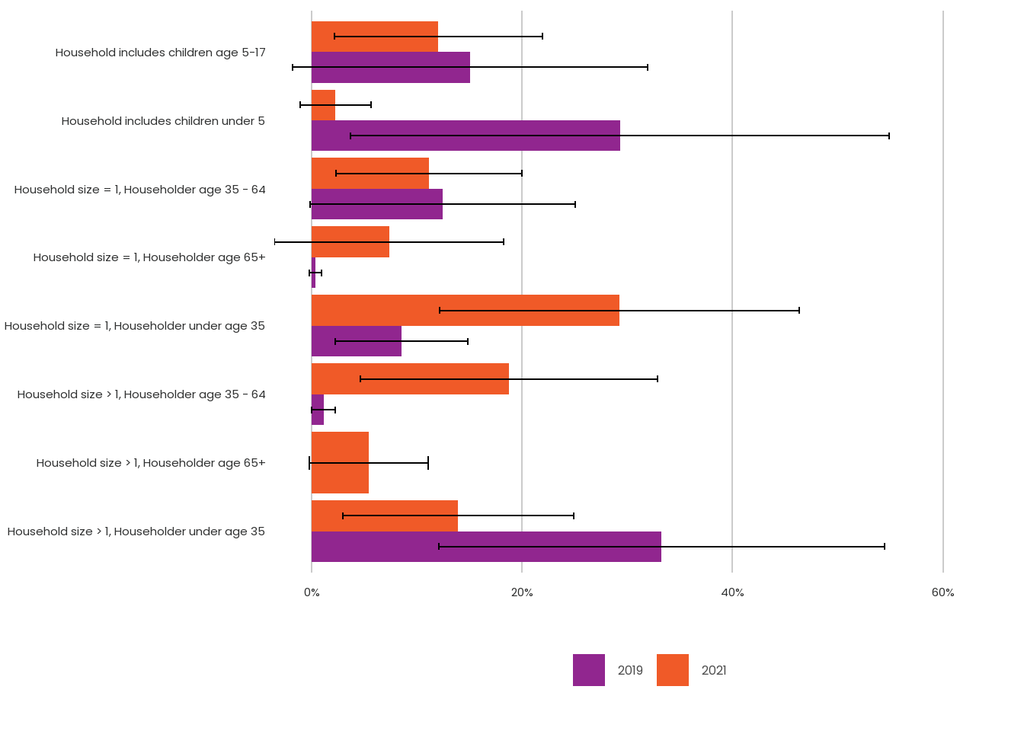

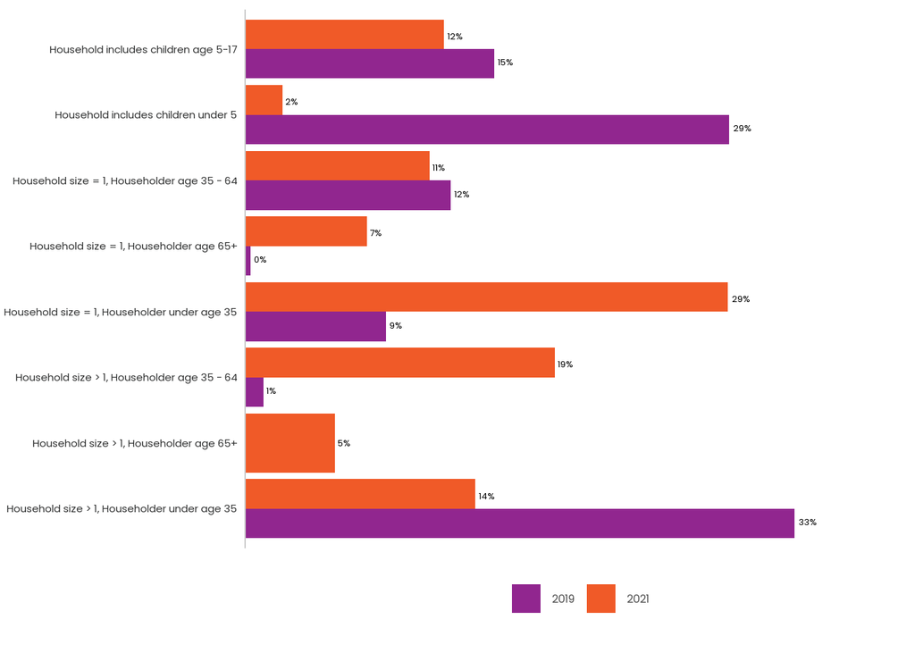

###### *Simplified life cycle*

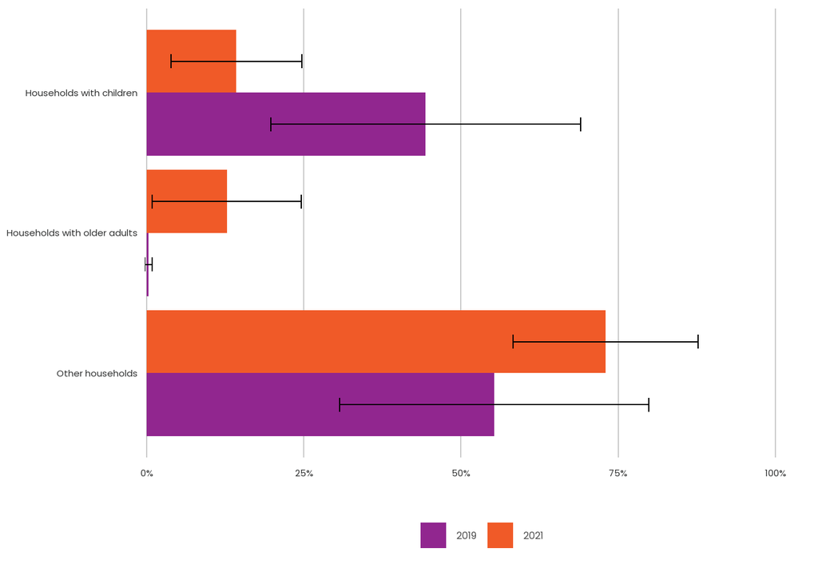

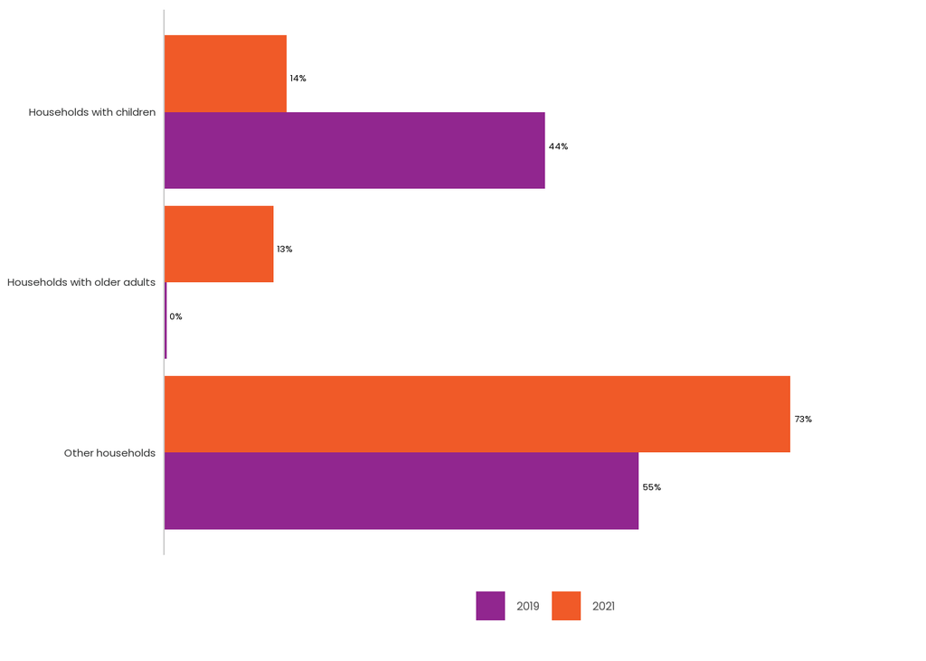

##### Tenure

###### Previous tenure

The majority of people who experienced displacement in both years were renters prior to moving.

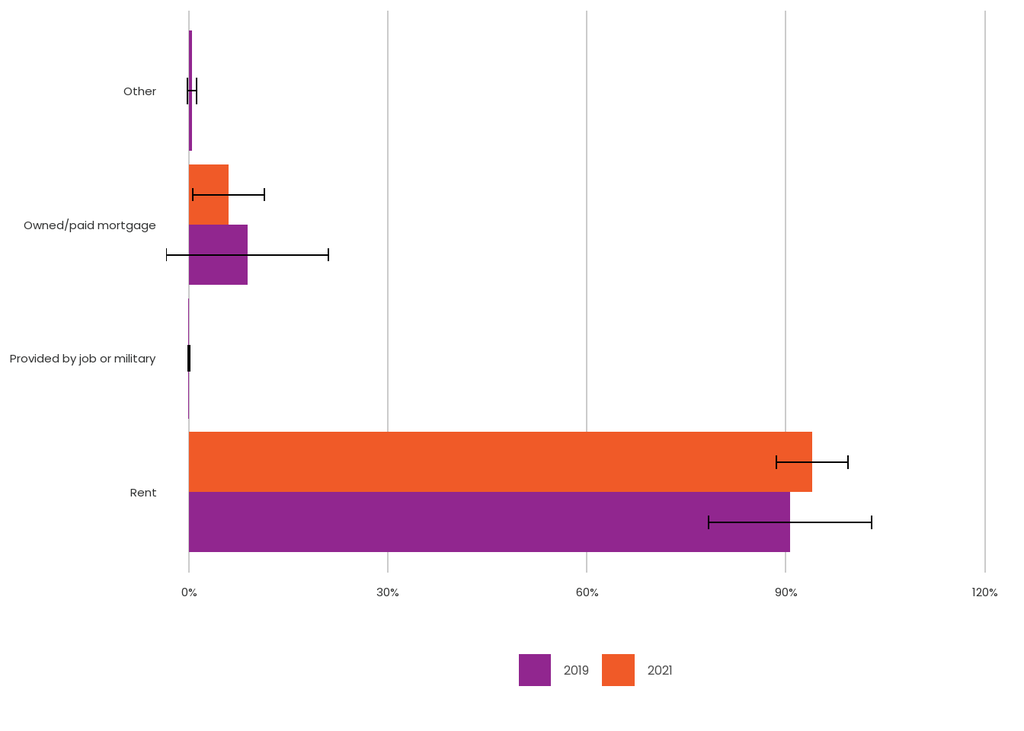

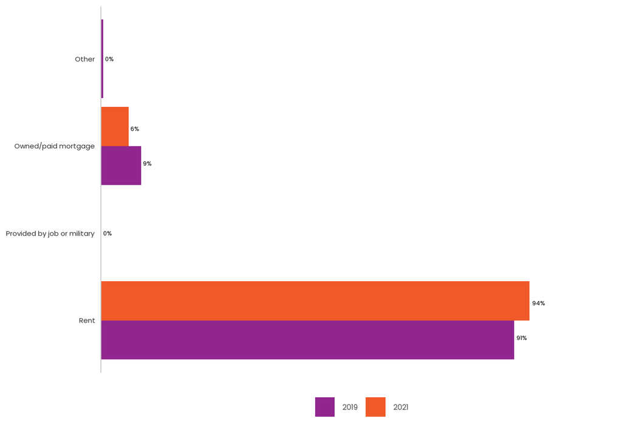

###### Current tenure

The majority of people who experienced displacement were renters at the time of the survey. Any changes between before and after covid are difficult to confirm because of the large, overlapping moes.

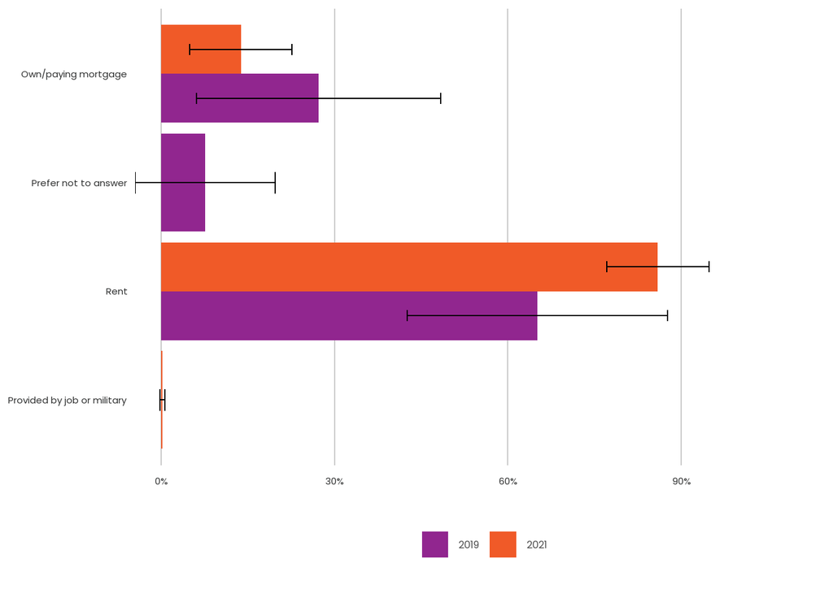

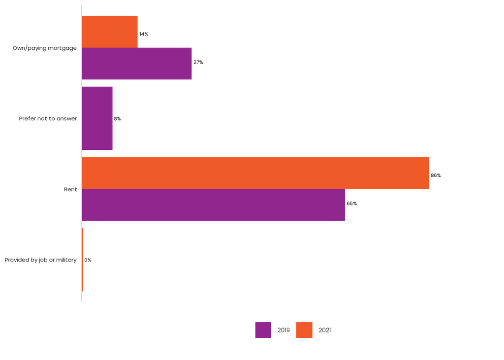

##### Residential type

###### Previous residential type

Large, overlapping moes.

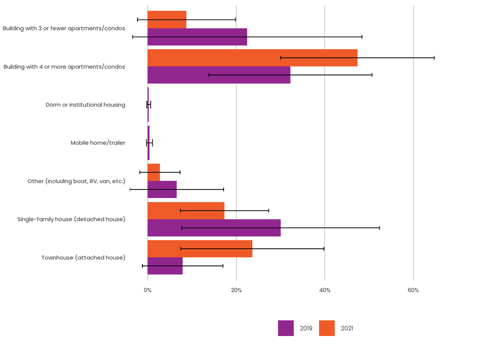

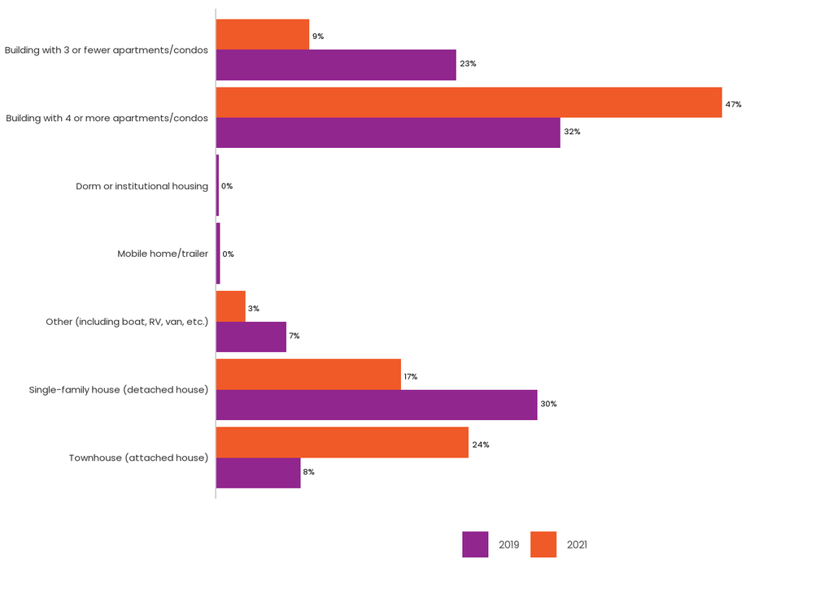

###### *Simplified previous*

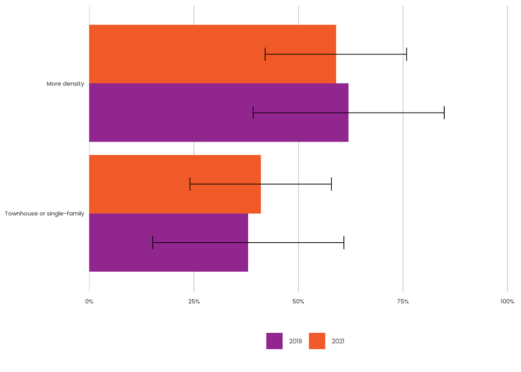

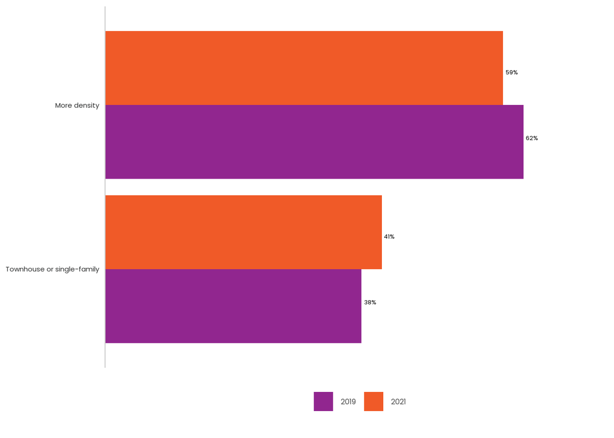

###### Current residential type

Large, overlapping moes.

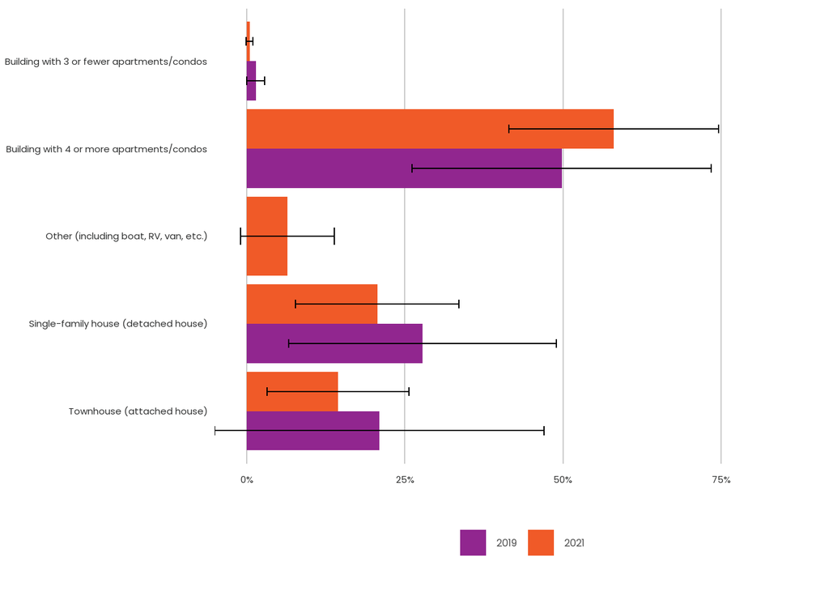

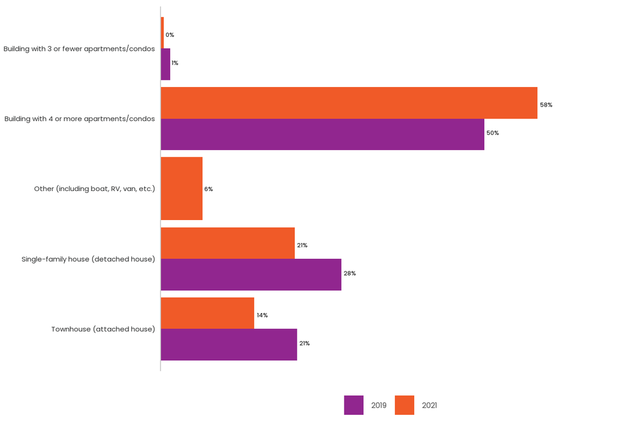

###### *Simplified current*

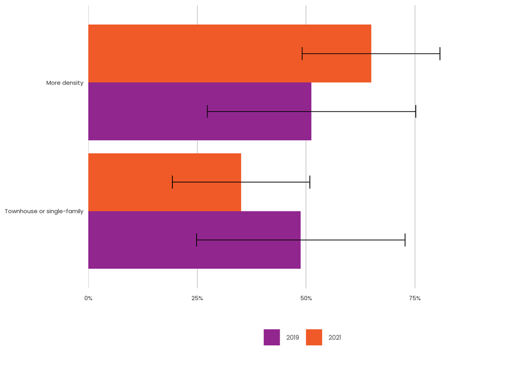

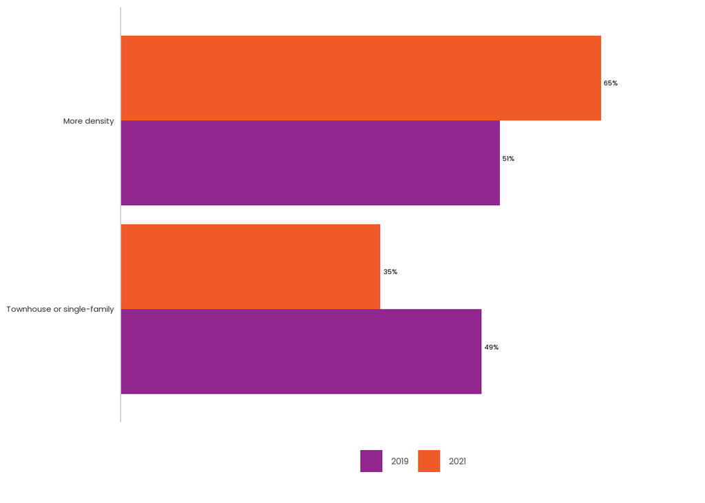